# Laboratorio 4 - Análisis Geoespacial y sensores remotos

### Sebastián Juárez - 21471

### Juan Pablo Cordón - 21458

Link al github: https://github.com/SebasJuarez/DS-Collection/tree/Lab4

Las imagenes, por cuestion de tiempo, se han incluido en documento images.ipynb: https://github.com/SebasJuarez/DS-Collection/blob/Lab4/Images.ipynb

## Analisis / primeros pasos de la busqueda de las imagenes

```python
import rasterio
import numpy as np
import matplotlib.pyplot as plt
from datetime import date
import openeo
```

```python
connection = openeo.connect("https://openeo.dataspace.copernicus.eu").authenticate_oidc()
```

```
Authenticated using refresh token.
```

### Toma de datos temporales basado en el ejemplo

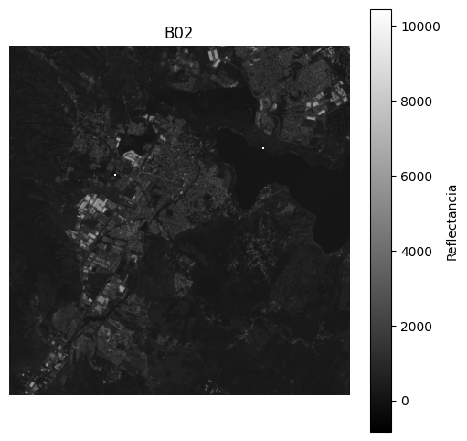

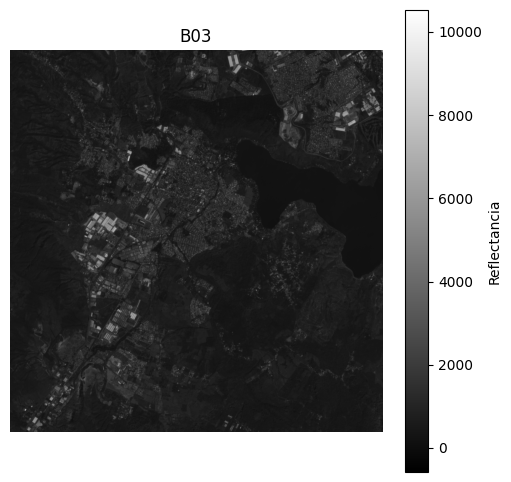

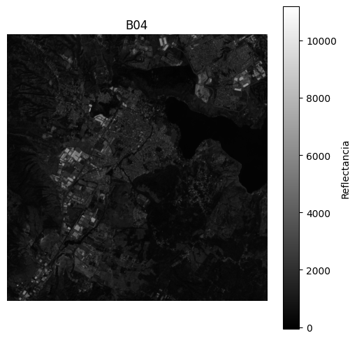

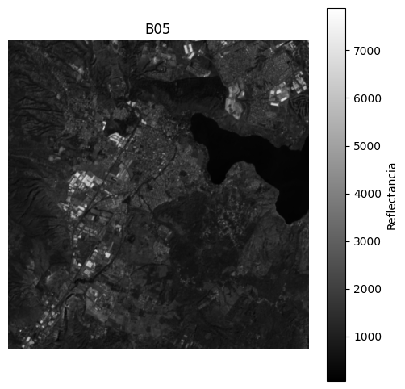

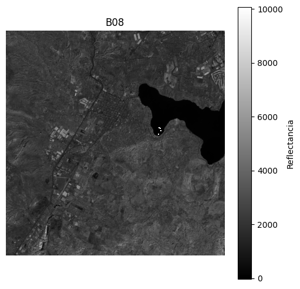

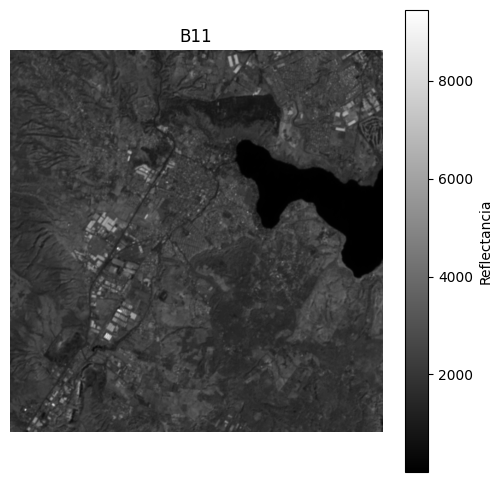

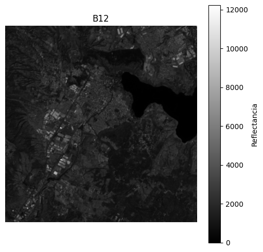

```python
import tempfile
import os

lago_atitlan = {
    "west": -91.31,
    "east": -91.08,
    "south": 14.60,
    "north": 14.74
}

lago_amatitlan = {
    "west": -90.66,
    "east": -90.58,
    "south": 14.43,
    "north": 14.51
}

fecha_inicio = "2025-02-07"
fecha_fin = "2025-02-07"

cube = connection.load_collection(
    "SENTINEL2_L2A",
    spatial_extent=lago_amatitlan,
    temporal_extent=[fecha_inicio, fecha_fin],
    bands=["B02", "B03", "B04", "B05", "B08", "B11", "B12"]
).max_time()

fd, temp_path = tempfile.mkstemp(suffix=".tif")
os.close(fd)

try:
    cube.download(temp_path)

    with rasterio.open(temp_path) as src:
        bandas = src.read()
        nombres = src.descriptions if src.descriptions[0] else [f"Banda {i+1}" for i in range(src.count)]
        nodata = src.nodata

    for i in range(bandas.shape[0]):
        plt.figure(figsize=(6, 6))
        img = bandas[i]
        img = np.ma.masked_where(img == nodata, img)
        plt.imshow(img, cmap='gray')
        plt.title(f"{nombres[i]}")
        plt.axis('off')
        plt.colorbar(label="Reflectancia")
        plt.show()

finally:
    os.remove(temp_path)
```

## Pruebas codigo Sentinel Hub para Cianobacterias

```
Authenticated using refresh token.
```

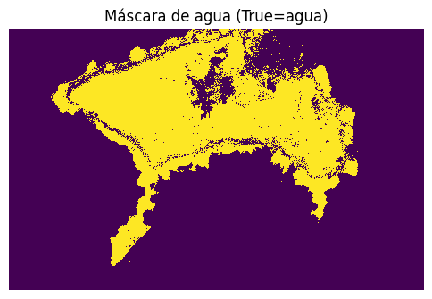

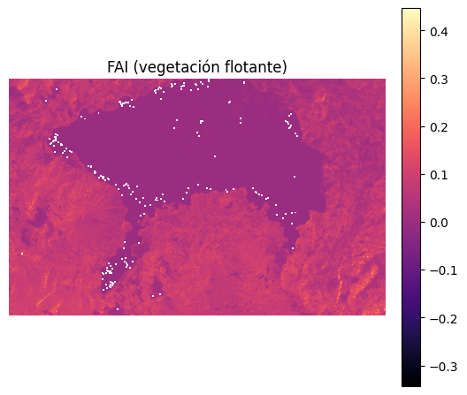

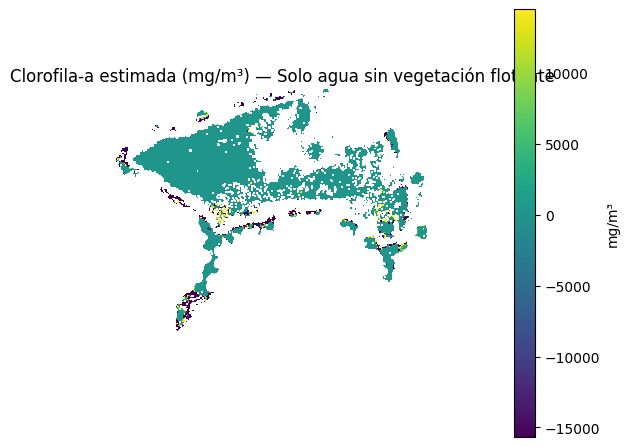

```python
import openeo
import numpy as np
import rasterio
import matplotlib.pyplot as plt
import os
import tempfile

bbox = {
    "west": -91.31,
    "east": -91.08,
    "south": 14.60,
    "north": 14.74
}
fecha_inicio = "2025-02-07"
fecha_fin = "2025-02-07"

MNDWI_threshold = 0.42
NDWI_threshold = 0.40
filter_UABS = True
filter_SSI = False

con = openeo.connect("https://openeo.dataspace.copernicus.eu").authenticate_oidc()

bands = ["B02","B03","B04","B05","B07","B8A","B08","B11","B12"]

cube = con.load_collection(
    "SENTINEL2_L2A",
    spatial_extent=bbox,
    temporal_extent=[fecha_inicio, fecha_fin],
    bands=bands
).max_time()

import os, tempfile
fd, temp_path = tempfile.mkstemp(suffix=".tif")
os.close(fd)

try:
    cube.download(temp_path)

    with rasterio.open(temp_path) as src:
        data = src.read()
        desc = src.descriptions
        nodata = src.nodata

    name_to_idx = { (desc[i] if desc and desc[i] else f"Banda {i+1}"): i for i in range(data.shape[0]) }

    def get_band(label, fallback_name):
        if desc and any(d for d in desc if d):
            for i, d in enumerate(desc):
                if d and label in d:
                    return data[i].astype("float32")
        i = bands.index(label)
        return data[i].astype("float32")

    B02 = get_band("B02", "B02")
    B03 = get_band("B03", "B03")
    B04 = get_band("B04", "B04")
    B05 = get_band("B05", "B05")
    B07 = get_band("B07", "B07")
    B8A = get_band("B8A", "B8A")
    B08 = get_band("B08", "B08")
    B11 = get_band("B11", "B11")
    B12 = get_band("B12", "B12")

    def mask_nodata(x):
        if nodata is not None:
            x = np.where(x == nodata, np.nan, x)
        return x

    for v in [B02,B03,B04,B05,B07,B8A,B08,B11,B12]:
        pass

    B02 = mask_nodata(B02); B03 = mask_nodata(B03); B04 = mask_nodata(B04)
    B05 = mask_nodata(B05); B07 = mask_nodata(B07); B8A = mask_nodata(B8A)
    B08 = mask_nodata(B08); B11 = mask_nodata(B11); B12 = mask_nodata(B12)

    def maybe_scale(x):
        p = np.nanpercentile(x, 99)
        return x/10000.0 if p > 2 else x

    B02 = maybe_scale(B02); B03 = maybe_scale(B03); B04 = maybe_scale(B04)
    B05 = maybe_scale(B05); B07 = maybe_scale(B07); B8A = maybe_scale(B8A)
    B08 = maybe_scale(B08); B11 = maybe_scale(B11); B12 = maybe_scale(B12)


    def ndvi(nir, r): return (nir - r) / (nir + r + 1e-6)
    def mndwi(g, swir1): return (g - swir1) / (g + swir1 + 1e-6)
    def ndwi(g, nir): return (g - nir) / (g + nir + 1e-6)
    def ndwi_leaves(nir, swir1): return (nir - swir1) / (nir + swir1 + 1e-6)
    def aweish(b, g, nir, swir1, swir2): return b + 2.5*g - 1.5*(nir + swir1) - 0.25*swir2
    def aweinsh(g, nir, swir1): return 4*(g - swir1) - (0.25*nir + 2.75*swir1)
    def dbsi(swir1, g, ndvi_): return ((swir1 - g) / (swir1 + g + 1e-6)) - ndvi_

    _ndvi = ndvi(B08, B04)
    _mndwi = mndwi(B03, B11)
    _ndwi = ndwi(B03, B08)
    _ndwi_leaves = ndwi_leaves(B08, B11)
    _aweish = aweish(B02, B03, B08, B11, B12)
    _aweinsh = aweinsh(B03, B08, B11)
    _dbsi = dbsi(B11, B03, _ndvi)

    water = (
        (_mndwi > MNDWI_threshold) |
        (_ndwi > NDWI_threshold) |
        (_aweinsh > 0.1879) |
        (_aweish > 0.1112) |
        (_ndvi < -0.2) |
        (_ndwi_leaves > 1)
    )

    if filter_UABS:
        water = np.where((water) & ((_aweinsh <= -0.03) | (_dbsi > 0)), False, water)

    FAIv = (B07 - (B04 + (B8A - B04) * (783 - 665) / (865 - 665)))

    NDCIv = (B05 - B04) / (B05 + B04 + 1e-6)
    chl = 826.57 * (NDCIv**3) - 176.43 * (NDCIv**2) + 19.0 * NDCIv + 4.071

    chl_masked = np.where((water) & (FAIv <= 0.08), chl, np.nan)

    plt.figure(figsize=(6,6))
    plt.imshow(water, interpolation="nearest")
    plt.title("Máscara de agua (True=agua)")
    plt.axis("off")
    plt.show()

    plt.figure(figsize=(6,6))
    im = plt.imshow(FAIv, cmap="magma")
    plt.title("FAI (vegetación flotante)")
    plt.axis("off")
    plt.colorbar(im, fraction=0.046, pad=0.04)
    plt.show()

    plt.figure(figsize=(6,6))
    im = plt.imshow(chl_masked, cmap="viridis", vmin=np.nanpercentile(chl_masked, 2), vmax=np.nanpercentile(chl_masked, 98))
    plt.title("Clorofila-a estimada (mg/m³) — Solo agua sin vegetación flotante")
    plt.axis("off")
    plt.colorbar(im, fraction=0.046, pad=0.04, label="mg/m³")
    plt.show()

finally:
    try:
        os.remove(temp_path)
    except Exception:
        pass
```

## Toma de datos crudos, sin imagenes, de los lagos

```python
print("=== BLOQUE 1: Configuración ===")

import os, json, tempfile, datetime as dt
import numpy as np
import pandas as pd
import matplotlib.pyplot as plt
import rasterio

# Coordenadas Lago Atitlán (WGS84)
lago_atitlan = {
    "west": -91.326256,
    "east": -91.071510,
    "south": 14.594800,
    "north": 14.750979,
}


# Fechas “buenas” que compartiste
fechas_buenas = [
    "2025-02-07","2025-02-10","2025-02-25","2025-02-27","2025-03-02",
    "2025-03-04","2025-03-07","2025-03-09","2025-03-12","2025-03-14",
    "2025-03-19","2025-03-22","2025-03-24","2025-03-26","2025-04-03",
    "2025-04-11","2025-04-13","2025-04-15","2025-04-16","2025-04-18",
    "2025-04-28","2025-05-03","2025-05-13","2025-05-28","2025-07-10",
    "2025-07-17","2025-07-20","2025-07-24","2025-08-01"
]

COVERAGE_THRESHOLD = 0.40  # % mínimo del lago cubierto para considerar la fecha
BANDS = ["B02","B03","B04","B05","B07","B8A","B08","B11","B12","SCL"]

print(f"Lago Atitlán bbox: {lago_atitlan}")
print(f"Fechas a procesar: {len(fechas_buenas)}")
print("Listo.")
```

```
=== BLOQUE 1: Configuración ===
Lago Atitlán bbox: {'west': -91.326256, 'east': -91.07151, 'south': 14.5948, 'north': 14.750979}
Fechas a procesar: 29
Listo.
```

```python
print("=== BLOQUE 2: Conexión openEO ===")
import openeo
con = openeo.connect("https://openeo.dataspace.copernicus.eu").authenticate_oidc()
print("Conectado a openEO. Autenticación lista.")
```

```
=== BLOQUE 2: Conexión openEO ===
Authenticated using refresh token.
Conectado a openEO. Autenticación lista.
```

```python
print("=== BLOQUE 3: Utilidades ===")
from affine import Affine
from pyproj import CRS, Transformer
import numpy as np

def scale01(x):
    # Escala 0..1 si vienen en 0..10000
    return x/10000.0 if np.nanpercentile(x, 99) > 2 else x

def mask_clouds_with_SCL(arr, scl):
    # SCL: 3 sombra, 7/8/9 nubes, 10 cirrus, 0/1 no data/borde
    bad = np.isin(scl, [0,1,3,7,8,9,10])
    out = arr.astype("float32").copy()
    out[bad] = np.nan
    return out

def water_mask(B02,B03,B04,B08,B11,B12):
    # Basado en script compartido (WBI + filtros UABS)
    ndvi_ = (B08-B04)/(B08+B04+1e-6)
    mndwi = (B03-B11)/(B03+B11+1e-6)
    ndwi_ = (B03-B08)/(B03+B08+1e-6)
    ndwi_leaves = (B08-B11)/(B08+B11+1e-6)
    aweish = B02 + 2.5*B03 - 1.5*(B08+B11) - 0.25*B12
    aweinsh = 4*(B03-B11) - (0.25*B08 + 2.75*B11)
    dbsi = ((B11-B03)/(B11+B03+1e-6)) - ndvi_

    water = (
        (mndwi > 0.42) |
        (ndwi_ > 0.40) |
        (aweinsh > 0.1879) |
        (aweish > 0.1112) |
        (ndvi_ < -0.2) |
        (ndwi_leaves > 1)
    )
    # filtrar urbano/suelo desnudo
    water = np.where((water) & ((aweinsh <= -0.03) | (dbsi > 0)), False, water)
    return water

def FAI(B04, B07, B8A):
    return B07 - (B04 + (B8A - B04) * (783 - 665) / (865 - 665))

def chlorophyll_from_NDCI(B04, B05):
    ndci = (B05 - B04)/(B05 + B04 + 1e-6)
    return 826.57*(ndci**3) - 176.43*(ndci**2) + 19.0*ndci + 4.071

def ndvi(NIR, RED):
    return (NIR - RED) / (NIR + RED + 1e-6)

def ndwi(GREEN, NIR):
    return (GREEN - NIR) / (GREEN + NIR + 1e-6)

def mask_with_bbox_any_crs(arr, transform, raster_crs, bbox_wgs84):
    """
    Recorta 'arr' (en el CRS del raster) con un bbox dado en WGS84.
    Convierte el bbox a CRS del raster y aplica la máscara.
    bbox_wgs84: dict con west/east/south/north (lon/lat).
    """
    if not isinstance(transform, Affine):
        transform = Affine(*transform)

    # grid de coordenadas en CRS del raster (X=Easting o lon; Y=Northing o lat)
    H, W = arr.shape
    yy, xx = np.indices((H, W))
    X = transform.c + xx*transform.a + yy*transform.b
    Y = transform.f + xx*transform.d + yy*transform.e

    try:
        # Transformar bbox WGS84 -> CRS del raster
        r_crs = CRS.from_user_input(raster_crs) if raster_crs is not None else CRS.from_epsg(4326)
        transformer = Transformer.from_crs(CRS.from_epsg(4326), r_crs, always_xy=True)
        x_w, y_s = transformer.transform(bbox_wgs84["west"],  bbox_wgs84["south"])
        x_e, y_n = transformer.transform(bbox_wgs84["east"],  bbox_wgs84["north"])

        xmin, xmax = (min(x_w, x_e), max(x_w, x_e))
        ymin, ymax = (min(y_s, y_n), max(y_s, y_n))

        inside = (X >= xmin) & (X <= xmax) & (Y >= ymin) & (Y <= ymax)
        out = arr.copy()
        out[~inside] = np.nan
        return out, inside
    except Exception as e:
        # Fallback: si algo falla, no recortamos
        print(f"[mask_with_bbox_any_crs] aviso: no se recortó por bbox ({e}).")
        return arr.copy(), np.ones_like(arr, dtype=bool)

def percentile_stretch(x, p_lo=2, p_hi=98):
    lo, hi = np.nanpercentile(x, (p_lo, p_hi))
    return np.clip((x - lo) / (hi - lo + 1e-6), 0, 1)

print("Funciones utilitarias cargadas.")
```

```
=== BLOQUE 3: Utilidades ===
Funciones utilitarias cargadas.
```

```python
print("=== BLOQUE 4: Descarga por fecha (ventana configurable) ===")
from openeo.processes import median as pmedian, max as pmax

# Configura la ventana temporal y el reductor
VENTANA_DIAS = 1
REDUCTOR = "max"

def get_bands_for_date(date_str):
    """Descarga bandas para 'date_str' con ventana configurable.
       Si VENTANA_DIAS==0 usa solo ese día; si >0 aplica reducción temporal según REDUCTOR."""
    date = pd.to_datetime(date_str).date()
    if VENTANA_DIAS == 0:
        t_start = t_end = date.isoformat()
    else:
        t_start = (date - dt.timedelta(days=VENTANA_DIAS)).isoformat()
        t_end   = (date + dt.timedelta(days=VENTANA_DIAS)).isoformat()

    print(f"[get_bands_for_date] Fecha {date_str} | ventana: {t_start} → {t_end}")

    cube = con.load_collection(
        "SENTINEL2_L2A",
        spatial_extent=lago_atitlan,
        temporal_extent=[t_start, t_end],
        bands=BANDS
    )

    # Reducir dimensión temporal solo si hay ventana > 0 y se definió REDUCTOR
    if VENTANA_DIAS > 0 and REDUCTOR is not None:
        if REDUCTOR == "median":
            print(" - Reductor temporal: MEDIANA")
            cube = cube.reduce_dimension(dimension="t", reducer=pmedian)
        elif REDUCTOR == "max":
            print(" - Reductor temporal: MÁXIMO")
            cube = cube.reduce_dimension(dimension="t", reducer=pmax)
        else:
            print(" - Reductor no reconocido; no se aplica reducción temporal.")
    else:
        print(" - Sin reducción temporal (día exacto o REDUCTOR=None).")

    # Descargar a archivo temporal (Windows-safe)
    fd, tmp = tempfile.mkstemp(suffix=".tif"); os.close(fd)
    cube.download(tmp)

    with rasterio.open(tmp) as src:
        data = src.read()             # (nbands, H, W)
        desc = src.descriptions
        nodata = src.nodata
        transform = src.transform
        crs = src.crs                 # <<--- NUEVO
        height, width = src.height, src.width
    try: os.remove(tmp)
    except: pass

    print(f"[get_bands_for_date] raster shape: {data.shape} (H={height}, W={width})")
    print(f"[get_bands_for_date] CRS: {crs}")  # <<--- NUEVO

    def band(label):
        if desc and any(d for d in desc):
            for i, d in enumerate(desc):
                if d and label in d:
                    return data[i].astype("float32")
        idx = BANDS.index(label)
        return data[idx].astype("float32")

    out = {b: band(b) for b in BANDS}
    out["transform"] = transform
    out["crs"] = crs            # <<--- NUEVO
    out["nodata"] = nodata
    return out

print("Función get_bands_for_date lista.")
```

```
=== BLOQUE 4: Descarga por fecha (ventana configurable) ===
Función get_bands_for_date lista.
```

```python
print("=== BLOQUE 5: Pipeline por fecha ===")
rows = []
per_date_maps = {}

for d in fechas_buenas:
    print(f"\n--- Procesando {d} ---")
    try:
        out = get_bands_for_date(d)
        B02,B03,B04,B05,B07,B8A,B08,B11,B12,SCL = [out[k] for k in BANDS]

        # NODATA -> NaN, escalar 0..1
        if out["nodata"] is not None:
            nod = out["nodata"]
            for k in ["B02","B03","B04","B05","B07","B8A","B08","B11","B12"]:
                x = out[k]
                x[x == nod] = np.nan
                out[k] = x

        B02,B03,B04,B05,B07,B8A,B08,B11,B12 = map(scale01, (B02,B03,B04,B05,B07,B8A,B08,B11,B12))

        # Recorte exacto al lago (si hay usando coordenadas) SOLO en B04 para definir 'inside'
        B04, inside = mask_with_bbox_any_crs(B04, out["transform"], out["crs"], lago_atitlan)

        # Aplicar máscara de nubes (SCL) y recorte al resto (incluye B04 ahora)
        def apply_masks(x):
            # x = mask_clouds_with_SCL(x, SCL)
            x[~inside] = np.nan
            return x

        B02 = apply_masks(B02); B03 = apply_masks(B03); B04 = apply_masks(B04)
        B05 = apply_masks(B05); B07 = apply_masks(B07); B8A = apply_masks(B8A)
        B08 = apply_masks(B08); B11 = apply_masks(B11); B12 = apply_masks(B12)

        # Agua (WBI + filtros). Calculado con bandas ya enmascaradas.
        water = water_mask(B02,B03,B04,B08,B11,B12)
        water = water & inside

        # Vegetación flotante
        fai = FAI(B04, B07, B8A)
        not_floating = ~(fai > 0.08)

        # Índices
        chl = chlorophyll_from_NDCI(B04, B05)
        ndvi_v = ndvi(B08, B04)
        ndwi_v = ndwi(B03, B08)

        # Aplicar máscaras finales
        chl = np.where(water & not_floating, chl, np.nan)
        ndvi_v = np.where(water, ndvi_v, np.nan)
        ndwi_v = np.where(water, ndwi_v, np.nan)

        # Coberturas
        poly_pixels  = int(np.sum(inside))
        water_pixels = int(np.sum(water))
        valid_pixels = int(np.sum(~np.isnan(chl)))

        coverage_pct_poly  = 0.0 if poly_pixels==0  else valid_pixels / poly_pixels
        coverage_pct_water = 0.0 if water_pixels==0 else valid_pixels / water_pixels

        # Prints de diagnóstico
        nan_ratio_chl  = 1 - (valid_pixels / (water_pixels if water_pixels>0 else 1))
        nan_ratio_ndvi = 1 - (np.sum(~np.isnan(ndvi_v)) / (water_pixels if water_pixels>0 else 1))
        nan_ratio_ndwi = 1 - (np.sum(~np.isnan(ndwi_v)) / (water_pixels if water_pixels>0 else 1))

        print(f"[{d}] poly_px={poly_pixels:,} | water_px={water_pixels:,} | "
              f"valid_px={valid_pixels:,} | cov_poly={coverage_pct_poly:.1%} | cov_water={coverage_pct_water:.1%}")
        print(f"      NaN ratios → chl:{nan_ratio_chl:.2f}  ndvi:{nan_ratio_ndvi:.2f}  ndwi:{nan_ratio_ndwi:.2f}")

        rows.append({
            "date": pd.to_datetime(d),
            "coverage_pct": coverage_pct_poly,          # para compatibilidad con el resto
            "coverage_pct_poly": coverage_pct_poly,
            "coverage_pct_water": coverage_pct_water,
            "chl_mean": float(np.nanmean(chl)),
            "chl_median": float(np.nanmedian(chl)),
            "chl_p95": float(np.nanpercentile(chl, 95)) if np.isfinite(np.nanmean(chl)) else np.nan,
            "ndvi_mean": float(np.nanmean(ndvi_v)),
            "ndwi_mean": float(np.nanmean(ndwi_v)),
            "valid_px": valid_pixels,
            "water_px": water_pixels
        })

        # Guardar mapa espacial acotado a 0–50 mg/m³ (para visual comparación)
        per_date_maps[d] = np.clip(chl, 0, 50)

    except Exception as e:
        print(f"[{d}] ERROR: {e}")
        rows.append({"date": pd.to_datetime(d), "error": str(e)})

print("\nTerminó el loop de fechas.")
```

```
=== BLOQUE 5: Pipeline por fecha ===

--- Procesando 2025-02-07 ---
[get_bands_for_date] Fecha 2025-02-07 | ventana: 2025-02-06 → 2025-02-08
 - Reductor temporal: MÁXIMO
[get_bands_for_date] raster shape: (10, 1751, 2759) (H=1751, W=2759)
[get_bands_for_date] CRS: PROJCS["WGS 84 / UTM zone 15N",GEOGCS["WGS 84",DATUM["World Geodetic System 1984",SPHEROID["WGS 84",6378137,298.257223563]],PRIMEM["Greenwich",0],UNIT["degree",0.0174532925199433,AUTHORITY["EPSG","9122"]]],PROJECTION["Transverse_Mercator"],PARAMETER["latitude_of_origin",0],…
[2025-02-07] poly_px=4,777,500 | water_px=982,048 | valid_px=981,862 | cov_poly=20.6% | cov_water=100.0%
      NaN ratios → chl:0.00  ndvi:0.00  ndwi:0.00

--- Procesando 2025-02-10 ---
[get_bands_for_date] Fecha 2025-02-10 | ventana: 2025-02-09 → 2025-02-11
 - Reductor temporal: MÁXIMO
[get_bands_for_date] raster shape: (10, 1751, 2759) (H=1751, W=2759)
[get_bands_for_date] CRS: PROJCS["WGS 84 / UTM zone 15N",GEOGCS["WGS 84",DATUM["World Geodetic System 1984",SPHEROID["WGS 84",6378137,298.257223563]],PRIMEM["Greenwich",0],UNIT["degree",0.0174532925199433,AUTHORITY["EPSG","9122"]]],PROJECTION["Transverse_Mercator"],PARAMETER["latitude_of_origin",0],…
[2025-02-10] poly_px=4,777,500 | water_px=1,258 | valid_px=1,258 | cov_poly=0.0% | cov_water=100.0%
      NaN ratios → chl:0.00  ndvi:0.00  ndwi:0.00

--- Procesando 2025-02-25 ---
[get_bands_for_date] Fecha 2025-02-25 | ventana: 2025-02-24 → 2025-02-26
 - Reductor temporal: MÁXIMO
[get_bands_for_date] raster shape: (10, 1751, 2759) (H=1751, W=2759)
[get_bands_for_date] CRS: PROJCS["WGS 84 / UTM zone 15N",GEOGCS["WGS 84",DATUM["World Geodetic System 1984",SPHEROID["WGS 84",6378137,298.257223563]],PRIMEM["Greenwich",0],UNIT["degree",0.0174532925199433,AUTHORITY["EPSG","9122"]]],PROJECTION["Transverse_Mercator"],PARAMETER["latitude_of_origin",0],…
[2025-02-25] poly_px=4,777,500 | water_px=236,316 | valid_px=236,316 | cov_poly=4.9% | cov_water=100.0%
      NaN ratios → chl:0.00  ndvi:0.00  ndwi:0.00

--- Procesando 2025-02-27 ---
[get_bands_for_date] Fecha 2025-02-27 | ventana: 2025-02-26 → 2025-02-28
 - Reductor temporal: MÁXIMO
[get_bands_for_date] raster shape: (10, 1751, 2759) (H=1751, W=2759)
[get_bands_for_date] CRS: PROJCS["WGS 84 / UTM zone 15N",GEOGCS["WGS 84",DATUM["World Geodetic System 1984",SPHEROID["WGS 84",6378137,298.257223563]],PRIMEM["Greenwich",0],UNIT["degree",0.0174532925199433,AUTHORITY["EPSG","9122"]]],PROJECTION["Transverse_Mercator"],PARAMETER["latitude_of_origin",0],…
[2025-02-27] poly_px=4,777,500 | water_px=1,284,646 | valid_px=1,284,579 | cov_poly=26.9% | cov_water=100.0%
      NaN ratios → chl:0.00  ndvi:0.00  ndwi:0.00

--- Procesando 2025-03-02 ---
[get_bands_for_date] Fecha 2025-03-02 | ventana: 2025-03-01 → 2025-03-03
 - Reductor temporal: MÁXIMO
[get_bands_for_date] raster shape: (10, 1751, 2759) (H=1751, W=2759)
[get_bands_for_date] CRS: PROJCS["WGS 84 / UTM zone 15N",GEOGCS["WGS 84",DATUM["World Geodetic System 1984",SPHEROID["WGS 84",6378137,298.257223563]],PRIMEM["Greenwich",0],UNIT["degree",0.0174532925199433,AUTHORITY["EPSG","9122"]]],PROJECTION["Transverse_Mercator"],PARAMETER["latitude_of_origin",0],…
[2025-03-02] poly_px=4,777,500 | water_px=136,144 | valid_px=136,144 | cov_poly=2.8% | cov_water=100.0%
```

[output cut: 62 more lines]

```
[get_bands_for_date] CRS: PROJCS["WGS 84 / UTM zone 15N",GEOGCS["WGS 84",DATUM["World Geodetic System 1984",SPHEROID["WGS 84",6378137,298.257223563]],PRIMEM["Greenwich",0],UNIT["degree",0.0174532925199433,AUTHORITY["EPSG","9122"]]],PROJECTION["Transverse_Mercator"],PARAMETER["latitude_of_origin",0],…
[2025-03-24] poly_px=4,777,500 | water_px=1,161,477 | valid_px=1,161,477 | cov_poly=24.3% | cov_water=100.0%
      NaN ratios → chl:0.00  ndvi:0.00  ndwi:0.00

--- Procesando 2025-03-26 ---
[get_bands_for_date] Fecha 2025-03-26 | ventana: 2025-03-25 → 2025-03-27
 - Reductor temporal: MÁXIMO
[get_bands_for_date] raster shape: (10, 1751, 2759) (H=1751, W=2759)
[get_bands_for_date] CRS: PROJCS["WGS 84 / UTM zone 15N",GEOGCS["WGS 84",DATUM["World Geodetic System 1984",SPHEROID["WGS 84",6378137,298.257223563]],PRIMEM["Greenwich",0],UNIT["degree",0.0174532925199433,AUTHORITY["EPSG","9122"]]],PROJECTION["Transverse_Mercator"],PARAMETER["latitude_of_origin",0],…
[2025-03-26] poly_px=4,777,500 | water_px=3,815 | valid_px=3,815 | cov_poly=0.1% | cov_water=100.0%
      NaN ratios → chl:0.00  ndvi:0.00  ndwi:0.00

--- Procesando 2025-04-03 ---
[get_bands_for_date] Fecha 2025-04-03 | ventana: 2025-04-02 → 2025-04-04
 - Reductor temporal: MÁXIMO
```

[output not shown]

[output cut: 65 more lines]

[output not shown]

```python
print("=== BLOQUE 6: Tabla + checks ===")
df = pd.DataFrame(rows).sort_values("date")
for col in ["coverage_pct_water","chl_mean","ndvi_mean","ndwi_mean","chl_median","chl_p95","valid_px"]:
    if col not in df.columns:
        df[col] = np.nan

print("Primeras filas:")
print(df.head(5).to_string(index=False))

if "error" in df.columns and df["error"].notna().any():
    print("\nErrores por fecha:")
    print(df.loc[df["error"].notna(), ["date","error"]].to_string(index=False))
else:
    print("\nSin errores reportados en fechas.")

print("\nResumen cobertura:")
print(df[["coverage_pct_water"]].describe())

df.to_csv("atitlan_indices_todas_las_fechas.csv", index=False)
```

```
=== BLOQUE 6: Tabla + checks ===
Primeras filas:
      date  coverage_pct  coverage_pct_poly  coverage_pct_water      chl_mean  chl_median     chl_p95  ndvi_mean  ndwi_mean  valid_px  water_px
2025-02-07      0.205518           0.205518            0.999811 -1.318510e+10    4.746356 1204.932007   0.904062   9.587302    981862    982048
2025-02-10      0.000263           0.000263            1.000000  4.040736e+00    4.260046    4.732763  -0.135770   0.436340      1258      1258
2025-02-25      0.049464           0.049464            1.000000  5.287579e-01    3.963018    4.691946   0.308929   0.595625    236316    236316
2025-02-27      0.268881           0.268881            0.999948  3.224710e+00    3.596182    4.517667  -0.143003   0.403314   1284579   1284646
2025-03-02      0.028497           0.028497            1.000000 -2.103549e+09    3.172209   10.806772   0.289753   0.760607    136144    136144

Sin errores reportados en fechas.

Resumen cobertura:
       coverage_pct_water
count           14.000000
mean             0.999886
std              0.000355
min              0.998664
25%              0.999988
50%              1.000000
75%              1.000000
max              1.000000
```

```
=== BLOQUE 7: Serie temporal + picos ===
Fechas consideradas (cobertura >= 40%): 14
         date  coverage_pct_water      chl_mean  ndvi_mean  ndwi_mean
0  2025-02-07            0.999811 -1.318510e+10   0.904062   9.587302
1  2025-02-10            1.000000  4.040736e+00  -0.135770   0.436340
2  2025-02-25            1.000000  5.287579e-01   0.308929   0.595625
3  2025-02-27            0.999948  3.224710e+00  -0.143003   0.403314
4  2025-03-02            1.000000 -2.103549e+09   0.289753   0.760607
5  2025-03-04            0.999989  1.684825e+00  -0.047707   0.383711
6  2025-03-07            1.000000 -2.045718e+10   0.660346   1.152470
7  2025-03-09            1.000000  3.153712e+00  -0.133639   0.428933
8  2025-03-12            1.000000  3.706319e+00  -0.004812   0.166499
9  2025-03-14            0.999999  2.433192e+00  -0.107496   0.462303
10 2025-03-19            0.999988  3.396026e+00  -0.111999   0.308703
11 2025-03-22            0.998664 -1.457839e+11  19.053434  21.067621
12 2025-03-24            1.000000  2.667520e+00  -0.131594   0.462572
13 2025-03-26            1.000000  3.049130e+00  -0.025212   0.475355
```

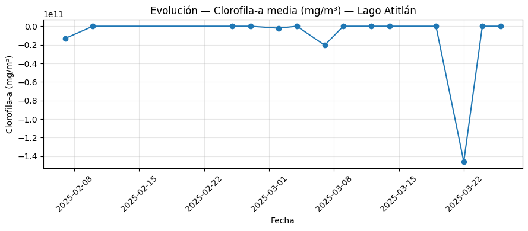

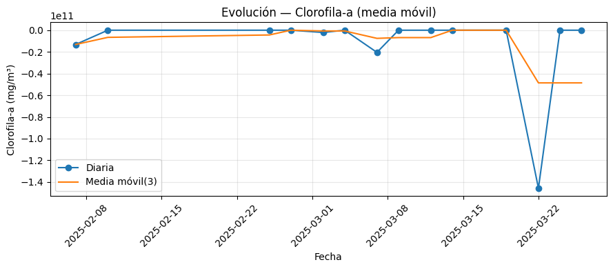

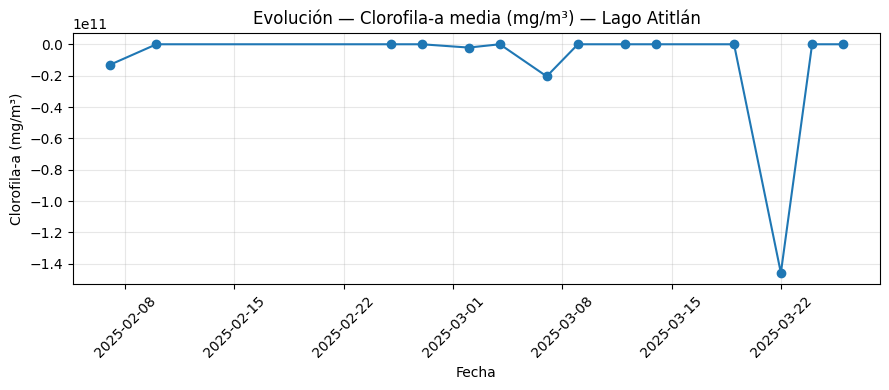

```
Top-3 picos por clorofila media:
      date  chl_mean  coverage_pct_water
2025-02-10  4.040736            1.000000
2025-03-12  3.706319            1.000000
2025-03-19  3.396026            0.999988
```

```python
print("=== BLOQUE 7: Serie temporal + picos ===")
df_good = df[df["coverage_pct_water"].fillna(0) >= COVERAGE_THRESHOLD].copy()

if df_good.empty:
    print(f"⚠️ No hay fechas con cobertura >= {COVERAGE_THRESHOLD:.0%}. "
          "Prueba bajar temporalmente el umbral o revisa SCL/fechas.")
else:
    print(f"Fechas consideradas (cobertura >= {COVERAGE_THRESHOLD:.0%}): {len(df_good)}")
    print(df_good[["date","coverage_pct_water","chl_mean","ndvi_mean","ndwi_mean"]])

    df_good.to_csv("atitlan_indices_temporales.csv", index=False)

    plt.figure(figsize=(9,4))
    plt.plot(df_good["date"], df_good["chl_mean"], marker="o")
    plt.title("Evolución — Clorofila-a media (mg/m³) — Lago Atitlán")
    plt.xlabel("Fecha"); plt.ylabel("Clorofila-a (mg/m³)")
    plt.grid(True, alpha=0.3); plt.xticks(rotation=45); plt.tight_layout()
    plt.show()
    plt.savefig("atitlan_serie_chl.png", dpi=200)

    df_good = df_good.sort_values("date")
    plt.figure(figsize=(9,4))
    plt.plot(df_good["date"], df_good["chl_mean"], marker="o", label="Diaria")
    plt.plot(df_good["date"], df_good["chl_mean"].rolling(3, min_periods=1).mean(), label="Media móvil(3)")
    plt.title("Evolución — Clorofila-a (media móvil)")
    plt.xlabel("Fecha"); plt.ylabel("Clorofila-a (mg/m³)")
    plt.grid(True, alpha=0.3); plt.legend(); plt.xticks(rotation=45); plt.tight_layout()
    plt.show()
    plt.savefig("atitlan_serie_chl_movil.png", dpi=200)

    plt.figure(figsize=(9,4))
    plt.plot(df_good["date"], df_good["chl_mean"], marker="o")
    plt.title("Evolución — Clorofila-a media (mg/m³) — Lago Atitlán")
    plt.xlabel("Fecha"); plt.ylabel("Clorofila-a (mg/m³)")
    plt.grid(True, alpha=0.3); plt.xticks(rotation=45); plt.tight_layout()
    plt.show()

    top_peaks = df_good.nlargest(3, "chl_mean")[["date","chl_mean","coverage_pct_water"]]
    print("\nTop-3 picos por clorofila media:")
    print(top_peaks.to_string(index=False))
```

```
=== BLOQUE 8: Mapas y correlaciones ===
Mejores coberturas: ['2025-02-10', '2025-02-25']
```

[figure not shown]

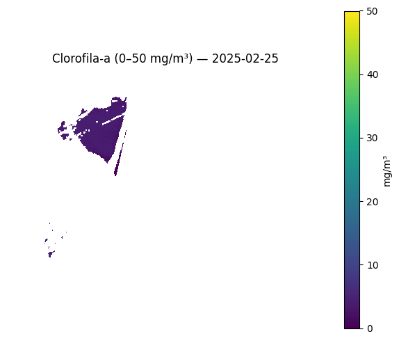

```
Fechas válidas para correlación: 14

Correlación Clorofila media (mg/m³) vs NDVI medio (n=14)
  Pearson r=-0.994 (p=7.81e-13) | Spearman ρ=-0.798 (p=0.000628)
```

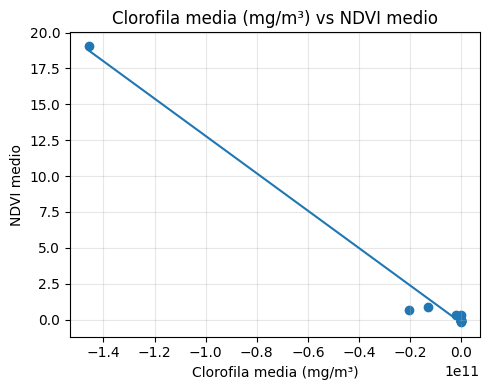

```
Correlación Clorofila media (mg/m³) vs NDWI medio (n=14)
  Pearson r=-0.934 (p=9.94e-07) | Spearman ρ=-0.833 (p=0.000217)
```

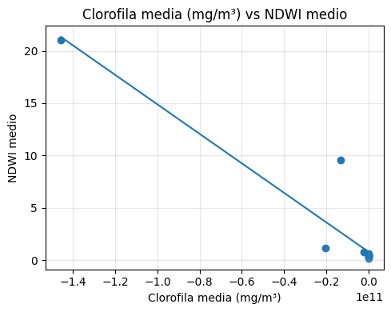

```python
print("=== BLOQUE 8: Mapas y correlaciones ===")

# Mapas (dos mejores coberturas)
if not df_good.empty:
    best_two = df_good.nlargest(2, "coverage_pct_water")["date"].dt.strftime("%Y-%m-%d").tolist()
    if len(best_two) < 2:
        print(f"Solo {len(best_two)} fecha(s) con buena cobertura: {best_two}")
    else:
        print(f"Mejores coberturas: {best_two}")
    for d in best_two:
        arr = per_date_maps.get(d)
        if arr is None:
            print(f"[Mapa] No hay raster cache para {d}")
            continue
        plt.figure(figsize=(6,5))
        im = plt.imshow(arr, cmap="viridis")
        plt.title(f"Clorofila-a (0–50 mg/m³) — {d}")
        plt.axis("off"); plt.colorbar(im, label="mg/m³")
        plt.tight_layout(); plt.show()
        plt.savefig(f"atitlan_mapa_{d}.png", dpi=200)   # <-- guarda PNG
else:
    print("No hay fechas con buena cobertura para mapas comparativos.")

# Correlaciones (chl vs NDVI y NDWI)
from scipy.stats import pearsonr, spearmanr

def corr_report(x, y, labelx, labely, fname_stub=None):
    good = (~np.isnan(x)) & (~np.isnan(y))
    n = good.sum()
    if n >= 3:
        pr, pp = pearsonr(x[good], y[good])
        sr, sp = spearmanr(x[good], y[good])
        print(f"\nCorrelación {labelx} vs {labely} (n={n})")
        print(f"  Pearson r={pr:.3f} (p={pp:.3g}) | Spearman ρ={sr:.3f} (p={sp:.3g})")
        plt.figure(figsize=(5,4))
        plt.scatter(x[good], y[good])
        m, b = np.polyfit(x[good], y[good], 1)
        xx = np.linspace(np.nanmin(x[good]), np.nanmax(x[good]), 100)
        plt.plot(xx, m*xx + b)
        plt.xlabel(labelx); plt.ylabel(labely)
        plt.title(f"{labelx} vs {labely}")
        plt.grid(True, alpha=0.3); plt.tight_layout(); plt.show()
        if fname_stub:
            plt.savefig(f"{fname_stub}.png", dpi=200)   # <-- guarda PNG
    else:
        print(f"Correlación {labelx} vs {labely}: datos insuficientes (n={n}).")

if not df_good.empty:
    print(f"Fechas válidas para correlación: {len(df_good)}")
    x_chl  = df_good["chl_mean"].values.astype(float)
    x_ndvi = df_good["ndvi_mean"].values.astype(float)
    x_ndwi = df_good["ndwi_mean"].values.astype(float)
    corr_report(x_chl, x_ndvi, "Clorofila media (mg/m³)", "NDVI medio", fname_stub="atitlan_corr_chl_ndvi")
    corr_report(x_chl, x_ndwi, "Clorofila media (mg/m³)", "NDWI medio", fname_stub="atitlan_corr_chl_ndwi")
else:
    print("Saltando correlaciones por falta de fechas válidas.")
```

En este caso no nos enfocamos en la busqueda de las imagenes, ya que mas que nada estamos buscando los indices de la clorofila dentro de estas imagenes. Dando un poco de contexto en la manera en la que funciona este codigo, va tomando las fechas que se nos dieron con menor nubosidad, verifica que tenga datos correctos (como por ejemplo que dentro del bloque de la imagen haya pixeles de agua). Utilizando las bandas de estas fechas, tomamos la informacion relacionada con una mascara de agua que nos dice el procentaje de clorofila en el agua. Basandonos en estos datos podemos calcular la cantidad de cianobacteria en el lago de atitlan.

Por que buscamos la clorofila-a? Esto es ya que es un pigmento que esta presente en las algas, o en este caso en la cianobacteria. Si hay un alto valor de clorofila-a, puede indicar que hay un aumento o proliferacion de cianobacterias. Esto no siempre es cierto, pero solo basandonos en Sentinel-2, puede llegar a ser un buen indicador

En el caso de NDVI, que es un indice de vegetación, un nivel alto nos puede indicar cosas como vegetacion flotante o hasta contaminacion en ciertos casos. En este caso, tenemos un indice negativo, que nos puede decir que no hay mucha vegetacion flotante o que hay pigmentos que interfieren con la toma de datos.

Por ultimo, viendo el NDWI, que mide el contenido de agua en la superficie, al tener una correlacion negativa, nos dice que cuando la concentracion de clorofila-a aumenta, el agua disminuye. Esto pude darse por confusiones en los colores resaltados tomandolos como agua limpia.